# Отчет по лабораторной работе №8

Лабораторная работа № 8

Бурлакова Алина

Российский университет дружбы народов, Москва, Россия

НБИбд-04-22

# Создание презентации

## Процессор `pandoc`

- Pandoc: преобразователь текстовых файлов
- Сайт: https://pandoc.org/
- Репозиторий: https://github.com/jgm/pandoc

## Формат `pdf`

- Использование LaTeX
- Пакет для презентации: beamer
- Тема оформления: `metropolis`

## Код для формата `pdf`

```yaml
slide_level: 2
aspectratio: 169
section-titles: true
theme: metropolis
```

## Формат `html`

- Используется фреймворк [reveal.js](https://revealjs.com/)
- Используется [тема](https://revealjs.com/themes/) `beige`

## Код для формата `html`

- Тема задаётся в файле `Makefile`

```
REVEALJS_THEME = beige
```

## Получающиеся форматы

- Полученный `pdf`-файл можно демонстрировать в любой программе просмотра `pdf`
- Полученный `html`-файл содержит в себе все ресурсы: изображения, css, скрипты

## Цели и задачи

Познакомиться с операционной системой Linux. Получить практические навыки рабо- ты с редактором vi, установленным по умолчанию практически во всех дистрибутивах

## Результаты

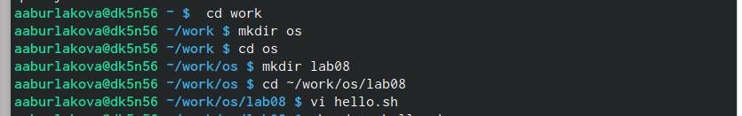

создание

2. В файле hello.sh вводим текст.Нажимаем клавишу Esc для перехода в командный режим после завершения ввода текста. Нажимаем : для перехода в режим последней строки и внизу вашего экрана появится приглашение в виде двоеточия. Нажимаем w (записать) и q (выйти), а затем нажимаем клавишу Enter для сохранения текста и завершения работы.

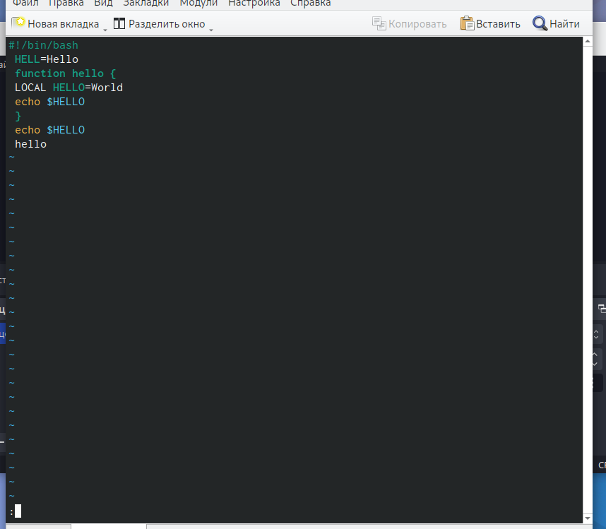

работа с файлом

3. Делаю файл исполняемым

4. Вызываем vi редактирование файла.

5. Установливаю курсор в конец слова HELL второй строки. Перехожу в режим вставки и заменяю на HELLO. Установливаю курсор на четвертую строку и стираю слово LOCAL. Перехожу в режим вставки и набираю следующий текст: local, нажмите Esc для возврата в командный режим. Устанавливаю курсор на последней строке файла. Вставьте после неё строку, содержащую следующий текст: echo $HELLO. Установите курсор в конец слова HELL второй строки.

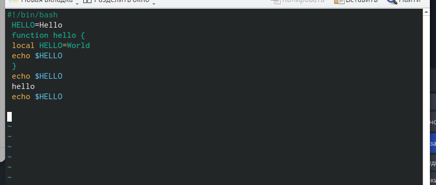

работа с файлом

## Вывод

В ходе лабораторной работы я познакомилась с операционной системой Linux. Получила практические навыки работы с редактором vi, установленным по умолчанию практически во всех дистрибутивах